# Regressão - speed dating

Vinicius Brandão Araújo

```r
library(tidyverse)
library(here)
library(broom)
library(modelr)
library(grid)
library(gridExtra)
```

## Objetivo da analise

Esta análise, realizada no contexto da disciplina Ciência de Dados 1, tem por objetivo analisar os dados que serão utilizados são referentes a encontros rápidos, também chamados de “speed dating”. Nesse tipo de encontro, diversas pessoas irão se conhecer, sendo cada par é sugerido por um sistema que foi alimentado com informações de cada participante e julga que aquele encontro deve acontecer. Após cada encontro, os participantes envolvidos deveriam preencher fichas avaliando a outra pessoa, com base em diversos critérios. Com isso, o conjunto de dados formado será analisado e perguntas envolvendo cada uma das variáveis foram elaboradas e serão respondidas neste relatório.

## Sobre os dados

Diversas varíaveis compõem o conjuno de dados. As informações detalhadas sobre cada uma delas pode ser vista [aqui](https://github.com/nazareno/ciencia-de-dados-1/tree/master/5-regressao/speed-dating).

```r
dados = na.omit(read.csv("https://raw.githubusercontent.com/nazareno/ciencia-de-dados-1/master/5-regressao/speed-dating/speed-dating.csv"))
```

## O que causa atração à primeira vista?

Para está pergunta consideramos que um encontro de 2 minutos entre os participantes, e assim algum aspectos são importante para atrai uma pessoa a primeira vista seria:

- fun : quão divertido p1 achou p2
- attr : quão atraente p1 achou p2
- shar : quanto p1 achou que compartilha interesses e hobbies com p2

Diante dessas caracteristicas escolhidas iremos observa o quanto ela podem está relacionada com like : no geral, quanto p1 gostou de p2, e assim podemos analisar diante das caracteristicas escolhidas a relação final se p1 gostou de p2. Para isso observamos o comportamento dessas caracteristicas em relação a like, a baixo:

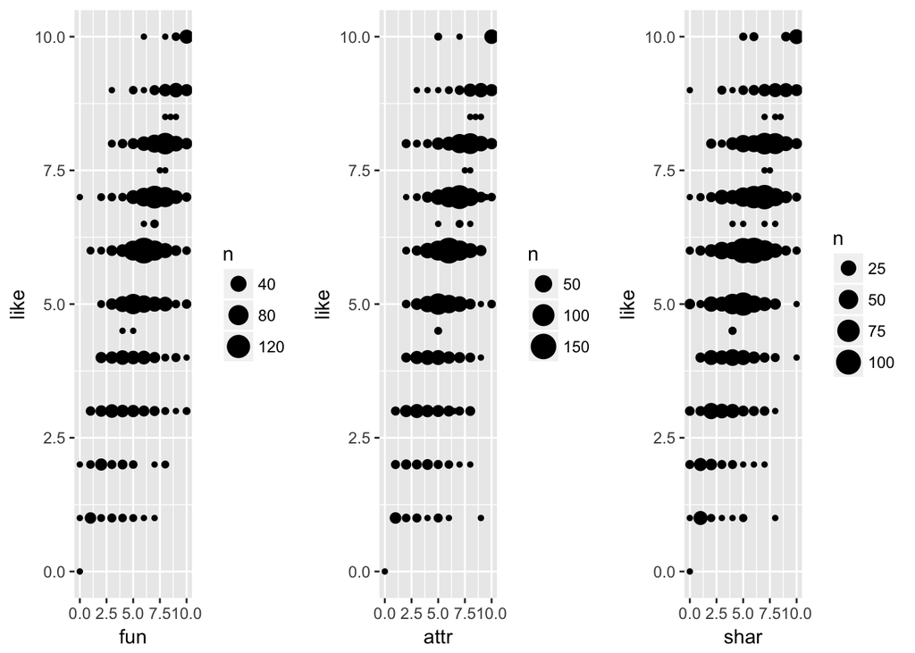

```r
p1<-dados %>%
    ggplot(aes(x = fun, y = like)) +
    geom_count()

p2<-dados %>%
    ggplot(aes(x = attr, y = like)) +
    geom_count()
p3<-dados %>%
    ggplot(aes(x = shar, y = like)) +
    geom_count()

grid.arrange(p1, p2,p3, nrow = 1)
```

Como podemos observar o comportamento dos gráfico em relação as caracteristicas com like é bem parecido, não tivemos uma variação visualmente considerada, mas como sabemos tirar conclusões apenas do que podemos observar pode gerar contradições e para melhorar nossa analise iremos utilizar:

- **regressão linear**: É uma equação para se estimar a condicional (valor esperado) de uma variável y, dados os valores de algumas outras variáveis x.A regressão, em geral, tem como objectivo tratar de um valor que não se consegue estimar inicialmente.

```r
modelo = lm(like ~ fun + shar + attr, data = dados)

tidy(modelo, conf.int = TRUE)
```

| term | estimate | std.error | statistic | p.value | conf.low | conf.high |
| --- | --- | --- | --- | --- | --- | --- |
| (Intercept) | 0.7807959 | 0.10265313 | 7.606158 | 4.761735e-14 | 0.5794488 | 0.9821429 |
| fun | 0.2508881 | 0.01876627 | 13.369093 | 9.607946e-39 | 0.2140793 | 0.2876968 |
| shar | 0.2669250 | 0.01545473 | 17.271411 | 1.779087e-61 | 0.2366116 | 0.2972384 |
| attr | 0.3709551 | 0.01761817 | 21.055256 | 3.543693e-87 | 0.3363983 | 0.4055120 |

```r
glance(modelo)
```

|  | r.squared | adj.r.squared | sigma | statistic | p.value | df | logLik | AIC | BIC | deviance | df.residual |
| --- | --- | --- | --- | --- | --- | --- | --- | --- | --- | --- | --- |
| 1 | 0.6453071 | 0.6446495 | 1.082583 | 981.231 | 0 | 4 | -2428.221 | 4866.442 | 4893.399 | 1896.273 | 1618 |